# Aedes aegypti in Brazil - Functional annotation of SNPs using SnpEff

Luciano V Cosme

2023-12-19

Analysis code

## 1. Load the libraries

```r
library(tidyverse)
library(here)
library(colorout)
library(dplyr)
library(flextable)
library(ggstatsplot)
library(ggplot2)
library(scales)
library(reticulate)
library(extrafont)
library(stringr)
library(flextable)
library(officer)
library(vroom)
library(gt)
library(ggrepel)
library(janitor)
```

## 2. Download SnpEff

We will used SnpEff to perform a functional annotation of our SNPs You can download the software [HERE](https://pcingola.github.io/SnpEff/). They have great documentation that it is worth checking it [HERE](https://pcingola.github.io/SnpEff/se_commandline/).

```bash
# move to the directory you want to download it
# Download and install SnpEff
curl -v -L 'https://snpeff.blob.core.windows.net/versions/snpEff_latest_core.zip' > snpEff_latest_core.zip
unzip snpEff_latest_core.zip
```

We can create a data base or use one that is already available. SnpEff documentation [HERE](https://pcingola.github.io/SnpEff/se_build_db_gff_gtf/):

```
There are three main steps when building a database:

Step 1: Configure a new genome in SnpEff's config file snpEff.config.
Step 2: Build using gene annotations and reference sequences
Step 3: Checking the database: SnpEff will check the database by comparing predicted protein sequences and CDS sequences with ones provided by the user.
```

Documentation regarding building database using GFF file:

```
GFF File name

SnpEff expects the GFF file to be located at


$SNPEFF_HOME/data/GENOME_NAME/genes.gff
where:

$SNPEFF_HOME is the directory where SnpEff is installed (usually $HOME/snpEff)
GENOME_NAME is the genome name of the genome you are trying to build, which MUST match the name you added in the config file snpEff.config
Note: The file name can be genes.gff.gz if it's compressed using gzip.
```

Check databases

```bash
java -Xmx8g -jar /Users/lucianocosme/Packages/snpEff/snpEff.jar databases | grep "aegypti"
#Aedes_aegypti_lvpagwg                                          Aedes_aegypti_lvpagwg                                           OK                                          https://snpeff.blob.core.windows.net/databases/v5_0/snpEff_v5_0_Aedes_aegypti_lvpagwg.zip
```

Download it

```bash
java -jar /Users/lucianocosme/Packages/snpEff/snpEff.jar download -v Aedes_aegypti_lvpagwg
# 00:00:00  SnpEff version SnpEff 5.0e (build 2021-03-09 06:01), by Pablo Cingolani
# 00:00:00  Command: 'download'
# 00:00:00  Reading configuration file 'snpEff.config'. Genome: 'Aedes_aegypti_lvpagwg'
# 00:00:00  Reading config file: /Users/lucianocosme/Library/CloudStorage/Dropbox/popgen/brazil/aegypti/snpEff.config
# 00:00:00  Reading config file: /Users/lucianocosme/Packages/snpEff/snpEff.config
# 00:00:00  done
# 00:00:00  Downloading database for 'Aedes_aegypti_lvpagwg'
# 00:00:01  Connecting to https://snpeff.blob.core.windows.net/databases/v5_0/snpEff_v5_0_Aedes_aegypti_lvpagwg.zip
# 00:00:01  Connecting to https://snpeff.blob.core.windows.net/databases/v5_0/snpEff_v5_0_Aedes_aegypti_lvpagwg.zip, using proxy: false
# 00:00:01  Local file name: '/var/folders/4q/74yqd6_94k97ywbkz0_wd9n80000gn/T//snpEff_v5_0_Aedes_aegypti_lvpagwg.zip'
# .........................
# 00:00:09  Download finished. Total 26863996 bytes.
# 00:00:09  Extracting file 'data/Aedes_aegypti_lvpagwg/snpEffectPredictor.bin'
# 00:00:09  Unzip: OK
# 00:00:09  Deleted local file '/var/folders/4q/74yqd6_94k97ywbkz0_wd9n80000gn/T//snpEff_v5_0_Aedes_aegypti_lvpagwg.zip'
# 00:00:09  Done
# 00:00:09  Logging
# 00:00:10  Done.
```

## 3. Run SnpEff

We prepared the vcf file after doing quality control.

```bash
java -Xmx8g -jar /Users/lucianocosme/Packages/snpEff/snpEff.jar Aedes_aegypti_lvpagwg output/populations/snps_sets/snpeff.vcf > output/snpeff/ann.vcf
```

Move files to output

```bash
# SnpEff will create a .txt and a .html file in our project root directory, we can move them to the right place
mv snpEff_* output/snpeff/
# you can double click the file snpEff_summary.html to see the summary of our annotation
```

Get types of variants

```bash
# i wrote a bash script to get the number of variants we have, you might have to run chmod 775 if you get permission denied
./scripts/analysis/variants_by_effect.sh output/snpeff/ann.vcf
```

Alternatively, we can create a file with the effects and how they are annotated in the vcf file

```bash
echo "Nonsynonymous missense_variant
Synonymous synonymous_variant
Intron intron_variant
Intergenic intergenic_region
3UTR 3_prime_UTR_variant
5UTR 5_prime_UTR" > output/snpeff/variant_types.txt
```

```bash
# not the most elegant but works
cat output/snpeff/variant_types.txt | while IFS=" " read -r variant effect
do
  echo "$variant"; cat output/snpeff/ann.vcf | sed '/##/d' | grep -c "$effect"
done | xargs -n2 > output/snpeff/annotations_summary.txt
```

Now, we can import it into R and make a table

```r
# import data
var_effects <- read_delim(
  here(
    "output", "snpeff", "annotations_summary.txt"
  ),
  col_names = FALSE,
  show_col_types = FALSE,
  col_types = "ci"
) |>
  rename(
    Effect            = 1,
    Number            = 2
  ) |>
  mutate(
    Effect = as.factor(
      Effect
    ),
    Percentage = prop.table(
      Number
    ) * 100,
    across(
      3, ~round(., 2)
    )
  ) |>
  arrange(
    -Percentage
  )

# make table
ftabv <- flextable(
  var_effects |>
  rename(
    Effect            = 1,
    "Number of SNPs"  = 2
  )
) |>
  set_caption(
    as_paragraph(
      as_chunk(
        "Variant effects for SNPs genotyped with the Chip",
        props         = fp_text_default(
          font.family = "Cambria"
        )
      )
    ),
    word_stylename    = "Table Caption"
  )

# Set theme
ftabv <- flextable::theme_zebra(ftabv)


# print(ftab, preview = "docx") # to open and see it in Microsoft Word.
ftabv
```

Variant effects for SNPs genotyped with the Chip

| Effect | Number of SNPs | Percentage |
| --- | --- | --- |
| Intron | 5,665 | 41.56 |
| Intergenic | 3,366 | 24.69 |
| Synonymous | 2,376 | 17.43 |
| 3UTR | 967 | 7.09 |
| Nonsynonymous | 630 | 4.62 |
| 5UTR | 628 | 4.61 |

```r
# save
# then you can open MS Word and make adjustments
ftabv |>
  autofit() |>
  save_as_docx(
    path = here(
      "output", "snpeff", "effect_type_and_number_SNPs.docx"
    )
  )
```

We can also make a plot of the effects

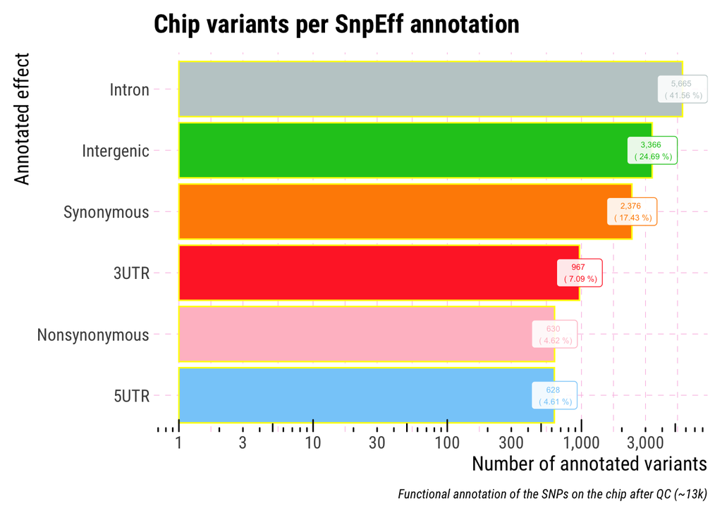

```r
# create vector of colors for our plot
# Wong, B. Points of view: Color blindness. Nat Methods (2011).
bla <- '#000000'
blu <- '#0072b2'
grb <- '#56b4e9'
lir <- '#cc79a7'
gre <- '#009e73'
red <- '#d55e00'
org <- '#e69f00'
yel <- '#f0e442'
gry <- '#BBBBBB'
#
# create vector
# option1
# special_colors <- list(
#   "Intron"        = "#BBBBBB",
#   "Intergenic"    = "#0072b2",
#   "Synonymous"    = "#009e73",
#   "5UTR"          = "#56b4e9",
#   "3UTR"          = "#cc79a7",
#   "Nonsynonymous" = "#d55e00"
# )
#
# Option 2
special_colors <- list(
  "Intron"        = "#C1CDCD",
  "Intergenic"    = "#1AC722",
  "Synonymous"    = "#FF8C00",
  "5UTR"          = "#87CEFA",
  "3UTR"          = "#FF3030",
  "Nonsynonymous" = "pink"
)
#
# make plot
var_effects |>
  mutate(                                   # we can use mutate to change the class of column
    Effect            = as.factor(          # we make column "Effect" factor
      Effect
      ),
    Effect = fct_reorder(                   # library forcats to re-order by the number of variants
       Effect, Number
      )
  ) |>
  ggplot() +
  geom_col(                                 # to make bar plot with different colors
    aes(                                    # mapping
      x               = Effect,
      y               = Number,
      fill            = Effect
    ),
    color             = "yellow"            # for the border
  ) +
  labs(                                     # to change the ylab and tittle
    title             = "Chip variants per SnpEff annotation",
    y                 = "Number of annotated variants",
    x                 = "Annotated effect",
    caption           = "Functional annotation of the SNPs on the chip after QC (~13k)"
  ) +
  hrbrthemes::theme_ipsum(                  # I like this theme, but you can use any
    base_family       = "Roboto Condensed", # needs to have extrafont library
    axis_text_size    = 12,
    axis_title_size   = 14,
    plot_margin       = margin(
      10, 10, 10, 10
    ),
    grid              = TRUE,
    grid_col          = "#fabbe2"
  ) +
   scale_fill_manual(
    values = unlist(
    special_colors
    )
  ) +
  scale_color_manual(
    values            = unlist(
    special_colors
    )
  ) +
  theme(
    legend.position   = "none",
    panel.grid.major  = element_line(
      linetype        = "dashed",
      linewidth       = 0.2,
    ),
    panel.grid.minor  = element_line(
      linetype        = "dashed",
      linewidth       = 0.2
    )
  ) +
  scale_y_continuous(
        trans = "log10",
        breaks = scales::log_breaks(
          n = 10
        ),
        labels = label_comma()
    ) +
  annotation_logticks(
    sides = "b"
  ) +
  geom_label(
    aes(
      x               = Effect,
      y               = Number,
      color           = Effect,
      label=paste(
        formatC(
          Number, format="f", big.mark = ",", digits=0
          ),"\n","(",Percentage,"%)"
      )
    ),
    face              = "bold",
    size              = 2,
    family            = "",
    alpha             = .9,
  ) +
  coord_flip()                             # to make it easier to read
```

```r
#
# save plot
ggsave(
  here(
    "output", "snpeff", "figures", "SNPs_effect_chip.pdf"
  ),
  width               = 10,
  height              = 4,
  units               = "in"
)
```

We can make variant lists based on their effect. It is useful for other analysis. However, since the annotation is not optimal, we have to be careful.

```bash
# variants from intergenic regions
sed '/##/d' output/snpeff/ann.vcf | grep "intergenic_region" | awk '{print $3}' > output/snpeff/intergenic_SNPs.txt
#
# variants from introns
sed '/##/d' output/snpeff/ann.vcf | grep "intron_variant" | awk '{print $3}' > output/snpeff/intron_SNPs.txt
#
# variants from 3'UTR
sed '/##/d' output/snpeff/ann.vcf | grep "3_prime_UTR_variant" | awk '{print $3}' > output/snpeff/3UTR_SNPs.txt
#
# variants from 5'UTR
sed '/##/d' output/snpeff/ann.vcf | grep "5_prime_UTR" | awk '{print $3}' > output/snpeff/5UTR_SNPs.txt
#
# variants from both 3 and 5'UTRs
sed '/##/d' output/snpeff/ann.vcf | grep "3_prime_UTR_variant\|5_prime_UTR" | awk '{print $3}' > output/snpeff/UTRs_SNPs.txt
#
# synonymous
sed '/##/d' output/snpeff/ann.vcf | grep "synonymous_variant" | awk '{print $3}' > output/snpeff/Synonymous_SNPs.txt
#
# nonsynonymous
sed '/##/d' output/snpeff/ann.vcf | grep "missense_variant" | awk '{print $3}' > output/snpeff/Nonsynonymous_SNPs.txt
```

We can also import the output of SnpEff into R

```r
# import SnpEff output
snpEff <-
  read_delim(
    here(
      "output", "snpeff", "snpEff_genes.txt"
    ),
    delim = '\t',
     comment = "# ",
    col_names = TRUE,
    show_col_types = FALSE
  ) |>
  rename(
    GeneName = 1
  )
# we can check the name of the columns
colnames(snpEff)
```

```
##  [1] "GeneName"
##  [2] "GeneId"
##  [3] "TranscriptId"
##  [4] "BioType"
##  [5] "variants_impact_HIGH"
##  [6] "variants_impact_LOW"
##  [7] "variants_impact_MODERATE"
##  [8] "variants_impact_MODIFIER"
##  [9] "variants_effect_3_prime_UTR_variant"
## [10] "variants_effect_5_prime_UTR_premature_start_codon_gain_variant"
## [11] "variants_effect_5_prime_UTR_variant"
## [12] "variants_effect_downstream_gene_variant"
## [13] "variants_effect_intron_variant"
## [14] "variants_effect_missense_variant"
## [15] "variants_effect_non_coding_transcript_exon_variant"
## [16] "variants_effect_splice_acceptor_variant"
## [17] "variants_effect_splice_donor_variant"
## [18] "variants_effect_splice_region_variant"
## [19] "variants_effect_start_lost"
## [20] "variants_effect_stop_gained"
## [21] "variants_effect_stop_lost"
## [22] "variants_effect_stop_retained_variant"
## [23] "variants_effect_synonymous_variant"
## [24] "variants_effect_upstream_gene_variant"
```

Lets get some gene counts

```r
# because the annotation was lifted from one genome assembly to a new one, we have some issues with the functional annotation. For example, we have genes missing start or stop codons, exons, etc. Therefore, we can focus on genes with the initial ID. SnpEff ties to annotate genes with missing exons or that have been broken up due to lifting.
# lets count how many genes we have starting with the letter LOC and remove rows with exons only
protein <-
  snpEff |>
  filter(
    !grepl(
      "exon",
      GeneName
    )
  ) |>
  filter(
    grepl(
      "AAEL",
      GeneName
    )
  ) |>
  count(
    BioType,
    sort = TRUE
  ) |>
  rename(
    "BioType of the gene"       = 1,
    "Number of genes with SNPs" = 2
  )
#
# make table
set_flextable_defaults(na_str = "NA", big.mark = ",")
ftabp <-
  flextable(
    protein
  ) |>
  set_caption(
    as_paragraph(
      as_chunk(
        "Number of genes with SNPs",
        props = fp_text_default(
          font.family = "Cambria"
        )
      )
    ),
    word_stylename = "Table Caption"
  )
#
# Apply zebra theme
ftabp <- flextable::theme_zebra(ftabp)
# print(ftab, preview = "docx") # to open and see it in Microsoft Word.
ftabp
```

Number of genes with SNPs

| BioType of the gene | Number of genes with SNPs |
| --- | --- |
| protein_coding | 13,525 |
| NA | 887 |
| pseudogene | 27 |
| rRNA | 7 |

```r
# save
# then you can open MS Word and make adjustments
ftabp |>
  autofit() |>
  save_as_docx(
    path = here(
      "output", "snpeff", "Number_of_genes_with_SNPs.docx"
    )
  )
```

The plot and statistics above are an approximation since the annotation was lifted, and we have more variant types I did not list. We could import the vcf to R, and parse it.

Import vcf to R.

```r
# following the code shared here https://joemcgirr.github.io/files/code_tutorials/my_genome/SnpEFF.html
start_time <- Sys.time()
# Wong, B. Points of view: Color blindness. Nat Methods (2011).
bla <- '#000000'
blu <- '#0072b2'
grb <- '#56b4e9'
lir <- '#cc79a7'
gre <- '#009e73'
red <- '#d55e00'
org <- '#e69f00'
yel <- '#f0e442'
gry <- '#BBBBBB'
#
# this step we did it earlier
# wget https://snpeff.blob.core.windows.net/versions/snpEff_latest_core.zip
# unzip snpEff_latest_core.zip
```

We need to get gatk to convert vcf to table

```bash
# you can run it on the terminal
wget \
https://github.com/broadinstitute/gatk/releases/download/4.3.0.0/gatk-4.3.0.0.zip \
--directory-prefix output/files
#
# decompress it
unzip \
/Users/lucianocosme/Dropbox/Albopictus/manuscript_chip/data/no_autogenous/albo_chip/output/files/gatk-4.3.0.0.zip \
-d /Users/lucianocosme/Packages
# export path
export PATH=$PATH:/Users/lucianocosme/Packages/gatk-4.3.0.0
#
```

Convert vcf to table

```bash
# export path
export PATH=$PATH:/Users/lucianocosme/Packages/gatk-4.3.0.0;

gatk \
VariantsToTable \
-V output/snpeff/ann.vcf \
-F CHROM -F POS -F TYPE -F ID -F ANN -F LOF -F NMD -GF AD -GF DP -GF GQ -GF GT \
-O output/snpeff/chip_ann.txt
```

Import data to R

```r
# read the data
ann <- vroom(
  here(
    "output", "SnpEff", "chip_ann.txt"
  ),
  guess_max = 1000000,
  show_col_types = FALSE
)
#
```

Create annotation types

```r
# table based on SnpEFF documentation
ann_types <- data.frame(
  impact = c(
    "HIGH", "HIGH", "HIGH", "HIGH", "HIGH", "HIGH", "HIGH", "HIGH", "HIGH", "HIGH", "MODERATE", "MODERATE", "MODERATE", "MODERATE", "MODERATE", "MODERATE", "MODERATE", "MODERATE", "MODERATE", "MODERATE", "MODERATE", "LOW", "LOW", "LOW", "LOW", "LOW", "LOW", "MODIFIER", "MODIFIER", "MODIFIER", "MODIFIER", "MODIFIER", "MODIFIER", "MODIFIER", "MODIFIER", "MODIFIER", "MODIFIER", "MODIFIER", "MODIFIER", "MODIFIER", "MODIFIER", "MODIFIER", "MODIFIER", "MODIFIER", "MODIFIER", "MODIFIER", "MODIFIER", "MODIFIER", "MODIFIER", "MODIFIER", "MODIFIER", "MODIFIER"
  ),
  ontology_term = c(
    "chromosome_number_variation", "exon_loss_variant", "frameshift_variant", "rare_amino_acid_variant", "splice_acceptor_variant", "splice_donor_variant", "start_lost", "stop_gained", "stop_lost", "transcript_ablation", "3_prime_UTR_truncation&exon_loss", "5_prime_UTR_truncation&exon_loss_variant", "coding_sequence_variant-moderate", "conservative_inframe_deletion", "conservative_inframe_insertion", "disruptive_inframe_deletion", "disruptive_inframe_insertion", "missense_variant", "regulatory_region_ablation", "splice_region_variant-moderate", "TFBS_ablation", "5_prime_UTR_premature_start_codon_gain_variant", "initiator_codon_variant", "splice_region_variant-low", "start_retained", "stop_retained_variant", "synonymous_variant", "3_prime_UTR_variant", "5_prime_UTR_variant", "coding_sequence_variant-modifier", "conserved_intergenic_variant", "conserved_intron_variant", "downstream_gene_variant", "exon_variant", "feature_elongation", "feature_truncation", "gene_variant", "intergenic_region", "intragenic_variant", "intron_variant", "mature_miRNA_variant", "miRNA", "NMD_transcript_variant", "non_coding_transcript_exon_variant", "non_coding_transcript_variant", "regulatory_region_amplification", "regulatory_region_variant", "TF_binding_site_variant", "TFBS_amplification", "transcript_amplification", "transcript_variant", "upstream_gene_variant"
  )
)
# check the possible variant annotations
ann_types |>
  gt() |>
  tab_header(
    title = "Putative impact for sequence ontology terms output by SnpEFF"
  )
```

Putative impact for sequence ontology terms output by SnpEFF

| impact | ontology_term |
| --- | --- |
| HIGH | chromosome_number_variation |
| HIGH | exon_loss_variant |
| HIGH | frameshift_variant |
| HIGH | rare_amino_acid_variant |
| HIGH | splice_acceptor_variant |
| HIGH | splice_donor_variant |
| HIGH | start_lost |
| HIGH | stop_gained |
| HIGH | stop_lost |
| HIGH | transcript_ablation |
| MODERATE | 3_prime_UTR_truncation&exon_loss |
| MODERATE | 5_prime_UTR_truncation&exon_loss_variant |
| MODERATE | coding_sequence_variant-moderate |
| MODERATE | conservative_inframe_deletion |
| MODERATE | conservative_inframe_insertion |
| MODERATE | disruptive_inframe_deletion |
| MODERATE | disruptive_inframe_insertion |
| MODERATE | missense_variant |
| MODERATE | regulatory_region_ablation |
| MODERATE | splice_region_variant-moderate |
| MODERATE | TFBS_ablation |
| LOW | 5_prime_UTR_premature_start_codon_gain_variant |
| LOW | initiator_codon_variant |
| LOW | splice_region_variant-low |
| LOW | start_retained |
| LOW | stop_retained_variant |
| LOW | synonymous_variant |
| MODIFIER | 3_prime_UTR_variant |
| MODIFIER | 5_prime_UTR_variant |
| MODIFIER | coding_sequence_variant-modifier |
| MODIFIER | conserved_intergenic_variant |
| MODIFIER | conserved_intron_variant |
| MODIFIER | downstream_gene_variant |
| MODIFIER | exon_variant |
| MODIFIER | feature_elongation |
| MODIFIER | feature_truncation |
| MODIFIER | gene_variant |
| MODIFIER | intergenic_region |
| MODIFIER | intragenic_variant |
| MODIFIER | intron_variant |
| MODIFIER | mature_miRNA_variant |
| MODIFIER | miRNA |
| MODIFIER | NMD_transcript_variant |
| MODIFIER | non_coding_transcript_exon_variant |
| MODIFIER | non_coding_transcript_variant |
| MODIFIER | regulatory_region_amplification |
| MODIFIER | regulatory_region_variant |
| MODIFIER | TF_binding_site_variant |
| MODIFIER | TFBS_amplification |
| MODIFIER | transcript_amplification |
| MODIFIER | transcript_variant |
| MODIFIER | upstream_gene_variant |

Make variant plots. First, get variant effect numbers

```r
# function to calculate the number of variants annotated for each ontology
# not my code, it is from https://joemcgirr.github.io/files/code_tutorials/my_genome/SnpEFF.html
n_variants <- c()
for (ot in ann_types$ontology_term) {
  n_variants <- c(n_variants, (filter(ann, grepl(ot, ANN)) |> nrow()))
  # print(ot)
}
#
# create new column and sort
ann_types$n_variants <- n_variants
ann_types <- arrange(ann_types, n_variants)
#
# set factors
ann_types$ontology_term <- factor(ann_types$ontology_term, levels = ann_types$ontology_term)
ann_types$impact <- factor(ann_types$impact, levels = c("HIGH","MODERATE","LOW","MODIFIER"))
```

Prepare data for plotting

```r
# arrange and remove those with those with no variants
ann_types2 <-
  ann_types |>
  mutate(
    ontology_term = str_remove_all(  # to remove the _variant from the column
      ontology_term, "_variant"
    )
  ) |>
  arrange(
    -n_variants, ann_types
  ) |>
  filter(
    !row_number() %in% c(1, 12)      # remove row with by index, we remove those that have the same values
  ) |>
  filter(
    n_variants > 0
  ) |>
  mutate(
    impact        = tolower(         # we use base R to convert all values on column Effect to lower case
      impact
    ),
    impact        = str_to_sentence( # here we use library stringr to convert the first letter to upper case
      impact
    ),
    ontology_term = str_to_sentence( # here we use library stringr to convert the first letter to upper case
      ontology_term
    ),
    across("ontology_term", ~str_replace(., "_", " ")),
    across("ontology_term", ~str_replace(., " prime_utr", "'UTR")),
    across("ontology_term", ~str_replace(., "_premature_start_codon_gain", " start codon gain")),
    across("ontology_term", ~str_replace(., "Missense", "Nonsynonymous")),
    ontology_term = factor(          # set ontology_term as factor
      ontology_term
    ),
    impact        = factor(          # set impact as factor
      impact
    ),
    Percentage    = prop.table(      # we use prop.table to calculate percentages
      n_variants
    ) * 100,
    across(                          # we use across to set column 3 as 2 decimals
      4, round, 2
    )
  ) |>
  rename(                            # to make impact start with capital letter
    Impact        = 1
  )
```

Make plot

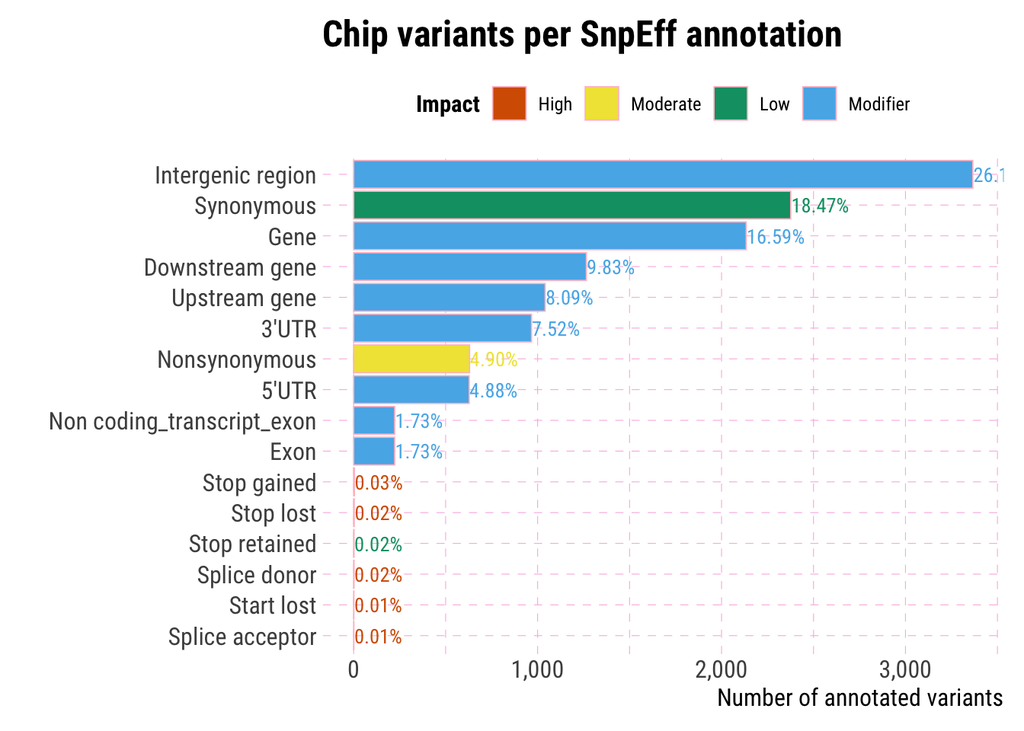

```r
# Wong, B. Points of view: Color blindness. Nat Methods (2011).
bla <- '#000000'
blu <- '#0072b2'
grb <- '#56b4e9'
lir <- '#cc79a7'
gre <- '#009e73'
red <- '#d55e00'
org <- '#e69f00'
yel <- '#f0e442'
gry <- '#BBBBBB'
#
# create colors
my_colors2 <- c(
  '#d55e00', '#f0e442', '#009e73','#56b4e9'
)
#
# create plot
p1 <-
  ann_types2 |>
  mutate(
    ontology_term     = fct_reorder(              # library forcats to re-order by the number of variants
      ontology_term, n_variants
    ),
    Impact            = fct_relevel(
      Impact,
      "High", "Moderate", "Low", "Modifier"
    ),
  ) |>
  ggplot(
    aes()
  ) +
  geom_col(                                       # to make colorful bar plot
    aes(
      x               = ontology_term,
      y               = n_variants,
      fill            = Impact
    ),
    color             = "pink",                   # for the border
    linewidth         = .3
  ) +
  coord_flip() +                                  # to make it easier to read
  hrbrthemes::theme_ipsum(
    base_family       = "Roboto Condensed",
    axis_text_size    = 12,
    axis_title_size   = 12,
    plot_margin       = margin(
      10, 10, 10, 10                              # top, right, bottom, left
    ),
    grid              = TRUE,
    grid_col          = "#fabbe2"
  ) +
  labs(
    y                 = "Number of annotated variants",
    x                 = "",
    title             = "Chip variants per SnpEff annotation"
  ) +
  geom_text(
    aes(
      y               = n_variants,
      x               = ontology_term,
      color           = Impact,
      label           = percent(
        Percentage / 100
      )                                          # we use library scales function to show percentage
    ),
    size              = 3.5,
    family            = "Roboto Condensed",
    hjust             = -0.01
  ) +
  scale_fill_manual(
    values            = my_colors2
  ) +
  scale_color_manual(
    values            = my_colors2
  ) +
  scale_y_continuous(
    labels            = comma
  ) +
  theme(
    legend.title      = element_text(
      family          = "Roboto Condensed",
      face            = "bold",
    ),
    legend.position   = "top",
    axis.title.x      = element_text(
      size            = 12
    ),
    axis.title.y      = element_text(
      size            = 12
    ),
    axis.title        = element_text(
      size            = 12
    ),
    axis.text         = element_text(
      size            = 12
    ),
    plot.title        = element_text(
      size            = 18,
      face            = "bold"
    ),
    panel.grid.major  = element_line(
      linetype        = "dashed",
      linewidth       = 0.2,
    ),
    panel.grid.minor  = element_line(
      linetype        = "dashed",
      linewidth       = 0.2
    )
  )
#
p1
```

```r
#
# save plot
ggsave(
  here(
    "output", "snpeff", "figures", "SNPs_effect_chip_plot2.pdf"
  ),
  width  = 11,
  height = 5,
  units  = "in"
)
```

The downside of this approach is importing the vcf into R. If you have millions of SNPs it is not doable.